# Stats with R and RStudio

Probabilité et statistique pour la biologie (STAT1)

Jacques van Helden

2017-09-12

# Scope

In this session we will explore basic manipulations of variables.

- Assigning a value to a variable
- Basic operations on numbers

# *R* is a calculator

**Convention:**

- Dark boxes: commands to type in RStudio **Console** (bottom-left panel).
- White boxes: the result you should obtain.

**Example:** compute a simple addition.

```r
2 + 5
```

```
[1] 7
```

# Assign a value to a variable

In *R* **`<-`** means “create a variable and assign its value.”

**Example:**

- create a variable named $a$,
- assign the value $2$ to this variable,
- *print* the result.

```r
a <- 2
print(a)
```

```
[1] 2
```

# Computing with variables

**Example:**

- create a variable named $b$ having value $5$,
- compute $a + b$ and store the result in a variable named $c$,
- *print* the result.

```r
b <- 5
c <- a + b
print(c)
```

```
[1] 7
```

# Variables need to be updated

**Example:**

- change the value of $a$ to $3$,
- print the value of $c$
- Is this the correct result for $c = a + b$? Why?

```r
a <- 3 ## Change the value of a
print(c) ## Print the value of c
```

```
[1] 7
```

```r
## Check whether c equals a + b
c == a + b
```

```
[1] FALSE
```

Note: **`==`** is used to test whether two variables have the same content.

# Updating variable contents

**Example:**

- change the value of $a$ to $27$,
- recompute and print the value of $c$

```r
a <- 27 ## Change the value of a
c <- a + b
print(c) ## Print the value of c
```

```
[1] 32
```

```r
## Check whether c  equals a + b
c == a + b
```

```
[1] TRUE
```

# Vectors of values

The simplest data structure in *R* is a vector. In the previous example, the variable *a* was actually a vector with a single value.

**Example:** create a variable named *three.numbers*, and initialize it with a vector with values *27*, *12* and *3000*.

**Tips:** - variable names can comprize several parts, separated by dots. - the function *`c()`* combines several values into a vector

```r
three.numbers <- c(27,12,3000)
print(three.numbers)
```

```
[1]   27   12 3000
```

# Series

The simple way to create a series of numbers. The column operator permits to generate all integer values between two limits.

```r
x <- 0:14
print(x)
```

```
 [1]  0  1  2  3  4  5  6  7  8  9 10 11 12 13 14
```

# Computing with vectors

**R** handles vectors in a very convenient way. An operation on a vector applies to all its elements.

```r
x <- 1:10 # Define a series from 1 to 10
print(x)
```

```
 [1]  1  2  3  4  5  6  7  8  9 10
```

```r
y <- x^2 # Compute the square of each number
print(y)
```

```
 [1]   1   4   9  16  25  36  49  64  81 100
```

# Scatter plot

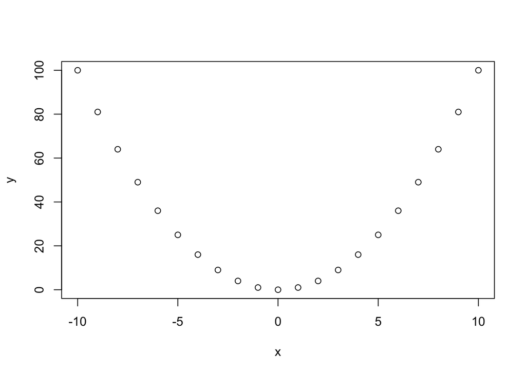

```r
x <- -10:10
y <- x^2
plot(x,y)
```